# Seminaroppgave 2

Author

Theodor Bredal-Thorsen

# 1 Seminar 2

# 2 Library

```r
library(tidyverse)
library(rosdata)
library(rstanarm)
library(conflicted)
library(ggplot2)
library(tinytable)
library(broom)
library(broom.mixed)
library(knitr)
library(modelsummary)
conflicts_prefer(dplyr::filter,
                 dplyr::select,
                 quanteda::stopwords,
                 rosdata::data)
```

# 3 Oppgave 1

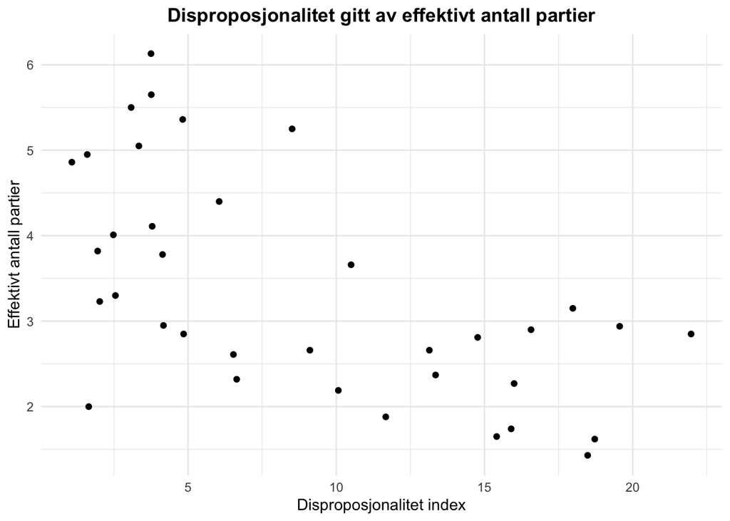

```r
dem_data <- read.csv("lijphart.csv")

scatter1 <- ggplot(dem_data, aes(y = eff_num_parl_parties_1981_2010, x = index_of_disproportionality_1981_2010,)) +
  geom_point() +
  labs(
    title = "Disproposjonalitet gitt av effektivt antall partier",
    y = "Effektivt antall partier",
    x= "Disproposjonalitet index"
  )+
  theme_minimal() +
  theme(plot.title = element_text(hjust = 0.5, face = "bold"))

scatter1
```

Plottet viser hvordan effektivt antall partier varierer over en index for disproporsjonalitet mellom andel stemmer og andel seter i demokratiske systemer. En kan kanskje se et mønster her, hvor disproporsjonale systemer har færre effektive partier enn proporsjonale systemer. Cut-offet ved 2 partier, hvor disproporsjonaliteten øker plutselig peker mot at systemer som favoriserer få partier, slik som i systemer med majoritære valgsystemer, er de som fanges opp av indeksen. (Se flott plot hos seminarleder!!)

# 4 Oppgave 2

```r
mod1 <-stan_glm(data = dem_data, eff_num_parl_parties_1981_2010 ~ 1, refresh = 0)

mod1_table <- tidy(mod1)

tt(mod1_table)
```

| term | estimate | std.error |
| --- | --- | --- |
| (Intercept) | 3.366486 | 0.2216312 |

```r
mod2 <- stan_glm(data = dem_data, eff_num_parl_parties_1981_2010 ~ index_of_disproportionality_1981_2010, refresh = 0)

mod2_table <- tidy(mod2, conf.int = TRUE)

tt(mod2_table)
```

| term | estimate | std.error | conf.low | conf.high |
| --- | --- | --- | --- | --- |
| (Intercept) | 4.4536137 | 0.30432238 | 3.9557337 | 4.96397984 |
| index_of_disproportionality_1981_2010 | -0.1236188 | 0.02696887 | -0.1702725 | -0.07687126 |